# Analyse des données Spatiales - Application sur le taux de criminalité

### 2.2 Représentation du taux de criminalité avec ggplot

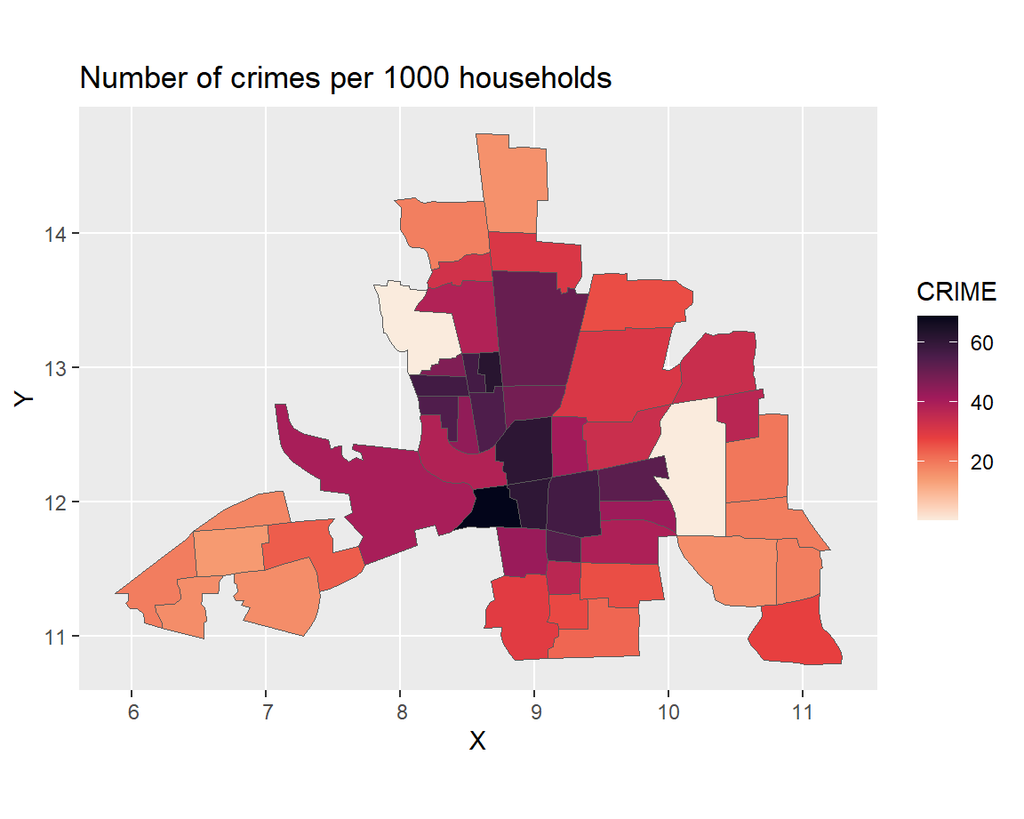

```r
ggplot(data = columbus) +
  geom_sf(aes(fill = CRIME)) +scale_fill_viridis_c(option="rocket",begin = 1,end=0)+
  xlab("X") + ylab("Y")+ggtitle("Number of crimes per 1000 households")
```

### 2.3 Représentation du taux de criminalité avec tmap

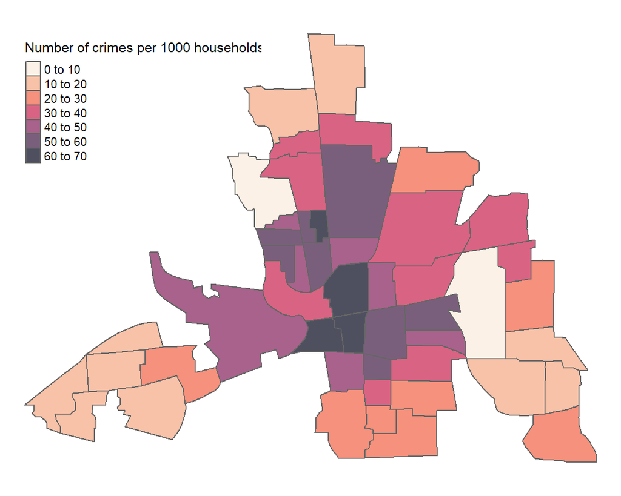

```r
tmap_mode("plot")
tm_shape(columbus) +
  tm_polygons(col="CRIME", alpha=0.7,pal = rocket(10, direction = -1),
              style="pretty", id="POLYID",
              title="Number of crimes per 1000 households")+
 tm_layout(frame = FALSE,bg.color="white")
```

```r
tmap_mode("view")
tm_shape(columbus) +
  tm_polygons(col="CRIME", alpha=0.7,pal = rocket(10, direction = -1),
              style="pretty", id="POLYID",
              title="Number of crimes per 1000 households")+
 tm_layout(frame = FALSE,bg.color="white")
```

[interactive chart not shown]

### 2.4 Représentation du revenu des ménages avec tmap

```r
tmap_mode("view")
tm_shape(columbus) +
  tm_polygons(col="INC", alpha=0.7,pal = rocket(10, direction = -1),
              style="pretty", id="POLYID",
              title="Household Income (1000$)")+
   tm_layout(frame = FALSE,bg.color="white")
```

[interactive chart not shown]

La comparaison des 2 cartes confirme la corrélation négative observée entre le taux de criminalité et le revenu.

## 3 Matrice de poids basée sur les 4 plus proches voisins

### 3.1 Identification et représentation des 4 plus proches voisins

utilisation de la fonction **knearneigh**

```r
coor<-st_centroid(st_geometry(columbus))
col.knn <- knearneigh(coor, k=4)
head(col.knn$nn)
```

```
     [,1] [,2] [,3] [,4]
[1,]    3    2    4    8
[2,]    4    1    8    3
[3,]    5    4    1    8
[4,]    8    2    7    3
[5,]   11    8    3   15
[6,]    9    5   10    3
```

Pour la représentation on converti l’objet knn en une liste de voisins avec la fonction **knn2nb**

```r
col.nb<- knn2nb(col.knn)

tmap_mode("view")
tm_shape(columbus)+tm_polygons(col="white", border.col = "grey25")+
  tm_shape(st_centroid(columbus))+tm_dots(size =0.05,col="red")+
  tm_shape(nb2lines(col.nb, coords=coor))+tm_lines(col="black", lwd=0.3)+
tm_layout(title ="Les 4 plus proches voisins",title.position = c('left', 'top'),frame = FALSE,bg.color="white")
```

[interactive chart not shown]

### 3.2 Construction de la matrice de poids spatiale des 4 plus proches voisins

Utilisation de la fonction nb2listw et de l’option standardisée

```r
W_KN4 <-nb2listw(col.nb,style="W")
summary(W_KN4)
```

```
Characteristics of weights list object:
Neighbour list object:
Number of regions: 49
Number of nonzero links: 196
Percentage nonzero weights: 8.163265
Average number of links: 4
Non-symmetric neighbours list
Link number distribution:

 4
49
49 least connected regions:
1 2 3 4 5 6 7 8 9 10 11 12 13 14 15 16 17 18 19 20 21 22 23 24 25 26 27 28 29 30 31 32 33 34 35 36 37 38 39 40 41 42 43 44 45 46 47 48 49 with 4 links
49 most connected regions:
1 2 3 4 5 6 7 8 9 10 11 12 13 14 15 16 17 18 19 20 21 22 23 24 25 26 27 28 29 30 31 32 33 34 35 36 37 38 39 40 41 42 43 44 45 46 47 48 49 with 4 links

Weights style: W
Weights constants summary:
   n   nn S0     S1  S2
W 49 2401 49 21.625 203
```

```r
head(W_KN4$neighbours)
```

```
[[1]]
[1] 2 3 4 8

[[2]]
[1] 1 3 4 8

[[3]]
[1] 1 4 5 8

[[4]]
[1] 2 3 7 8

[[5]]
[1]  3  8 11 15

[[6]]
[1]  3  5  9 10
```

```r
head(W_KN4$weights)
```

```
[[1]]
[1] 0.25 0.25 0.25 0.25

[[2]]
[1] 0.25 0.25 0.25 0.25

[[3]]
[1] 0.25 0.25 0.25 0.25

[[4]]
[1] 0.25 0.25 0.25 0.25

[[5]]
[1] 0.25 0.25 0.25 0.25

[[6]]
[1] 0.25 0.25 0.25 0.25
```

## 4 Matrice de poids spatiale basée sur la contiguité

### 4.1 Représentation des centroïdes

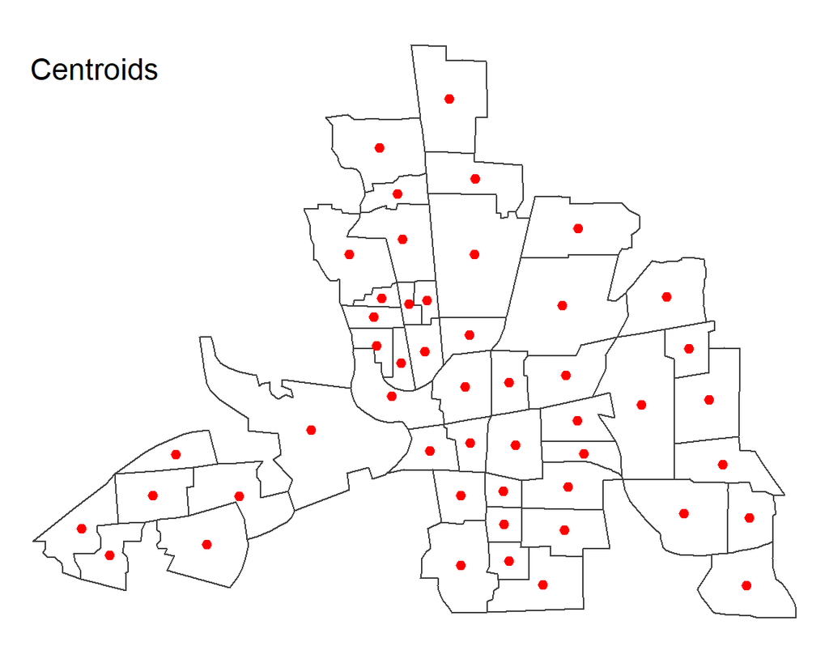

```r
tmap_mode("plot")
tm_shape(columbus)+tm_polygons(col="white", border.col = "grey25")+
 tm_layout(frame = FALSE,bg.color="white")+
  tm_shape(st_centroid(columbus))+tm_dots(size =0.2,col="red")+
  tm_layout(title ="Centroids",title.position = c('left', 'top'))
```

### 4.2 Contruction de la matrice de contiguité

- Identification des voisins avec la fonction **poly2nb** et représentation des liens

```r
mapC.nb<-poly2nb(columbus,queen = TRUE)
summary(mapC.nb)
```

```
Neighbour list object:
Number of regions: 49
Number of nonzero links: 236
Percentage nonzero weights: 9.829238
Average number of links: 4.816327
Link number distribution:

 2  3  4  5  6  7  8  9 10
 5  9 12  5  9  3  4  1  1
5 least connected regions:
1 6 42 46 47 with 2 links
1 most connected region:
20 with 10 links
```

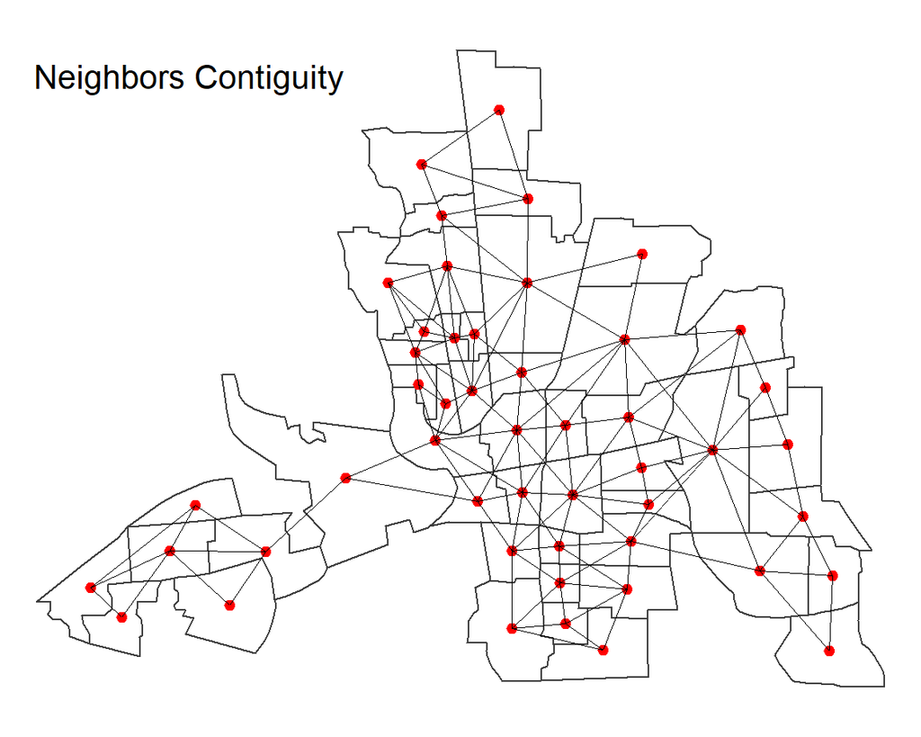

```r
tm_shape(columbus)+tm_polygons(col="white", border.col = "grey25")+
  tm_shape(st_centroid(columbus))+tm_dots(size = .2,col="red")+
  tm_shape(nb2lines(mapC.nb, coords=coor))+tm_lines(col="black", lwd=0.3)+
  tm_layout(title ="Neighbors Contiguity",title.position = c('left', 'top'),frame = FALSE)
```

- création de la matrice de poids standardisée avec la fonction **nb2listw**

```r
col.listw<-nb2listw(mapC.nb,style="W")
summary(col.listw)
```

```
Characteristics of weights list object:
Neighbour list object:
Number of regions: 49
Number of nonzero links: 236
Percentage nonzero weights: 9.829238
Average number of links: 4.816327
Link number distribution:

 2  3  4  5  6  7  8  9 10
 5  9 12  5  9  3  4  1  1
5 least connected regions:
1 6 42 46 47 with 2 links
1 most connected region:
20 with 10 links

Weights style: W
Weights constants summary:
   n   nn S0       S1       S2
W 49 2401 49 22.75119 203.7091
```

## 5 Spatial lag du taux de criminalité

- La fonction **lag.listw** permet de créer le spatial lag de la variable et vérification des calculs

```r
xx <- cbind(columbus$CRIME,columbus$INC,columbus$HOVAL)
head(xx)
```

```
         [,1]   [,2]   [,3]
[1,] 15.72598 19.531 80.467
[2,] 18.80175 21.232 44.567
[3,] 30.62678 15.956 26.350
[4,] 32.38776  4.477 33.200
[5,] 50.73151 11.252 23.225
[6,] 26.06666 16.029 28.750
```

```r
wxx <- lag.listw(col.listw,xx)
head(wxx)
```

```
         [,1]     [,2]     [,3]
[1,] 24.71427 18.59400 35.45850
[2,] 26.24684 13.32133 46.67233
[3,] 29.41175 14.12300 45.36475
[4,] 34.64648 14.94425 32.81675
[5,] 40.46533 11.29375 29.31562
[6,] 40.62371 14.41900 37.91250
```

```r
attributes(col.listw)
```

```
$names
[1] "style"      "neighbours" "weights"

$class
[1] "listw" "nb"

$region.id
 [1] "1"  "2"  "3"  "4"  "5"  "6"  "7"  "8"  "9"  "10" "11" "12" "13" "14" "15"
[16] "16" "17" "18" "19" "20" "21" "22" "23" "24" "25" "26" "27" "28" "29" "30"
[31] "31" "32" "33" "34" "35" "36" "37" "38" "39" "40" "41" "42" "43" "44" "45"
[46] "46" "47" "48" "49"

$call
nb2listw(neighbours = mapC.nb, style = "W")

$zero.policy
[1] FALSE
```

```r
col.listw$neighbours[1]
```

```
[[1]]
[1] 2 3
```

```r
col.listw$weights[1]
```

```
[[1]]
[1] 0.5 0.5
```

```r
(xx[2,] + xx[3,])/2.0
```

```
[1] 24.71427 18.59400 35.45850
```

```r
wxx[1,]
```

```
[1] 24.71427 18.59400 35.45850
```

```r
col.listw$neighbours[2]
```

```
[[1]]
[1] 1 3 4
```

```r
(xx[1,] + xx[3,] + xx[4,] )/3.0
```

```
[1] 26.24684 13.32133 46.67233
```

```r
wxx[2,]
```

```
[1] 26.24684 13.32133 46.67233
```

- Comparaison des statistiques descriptives

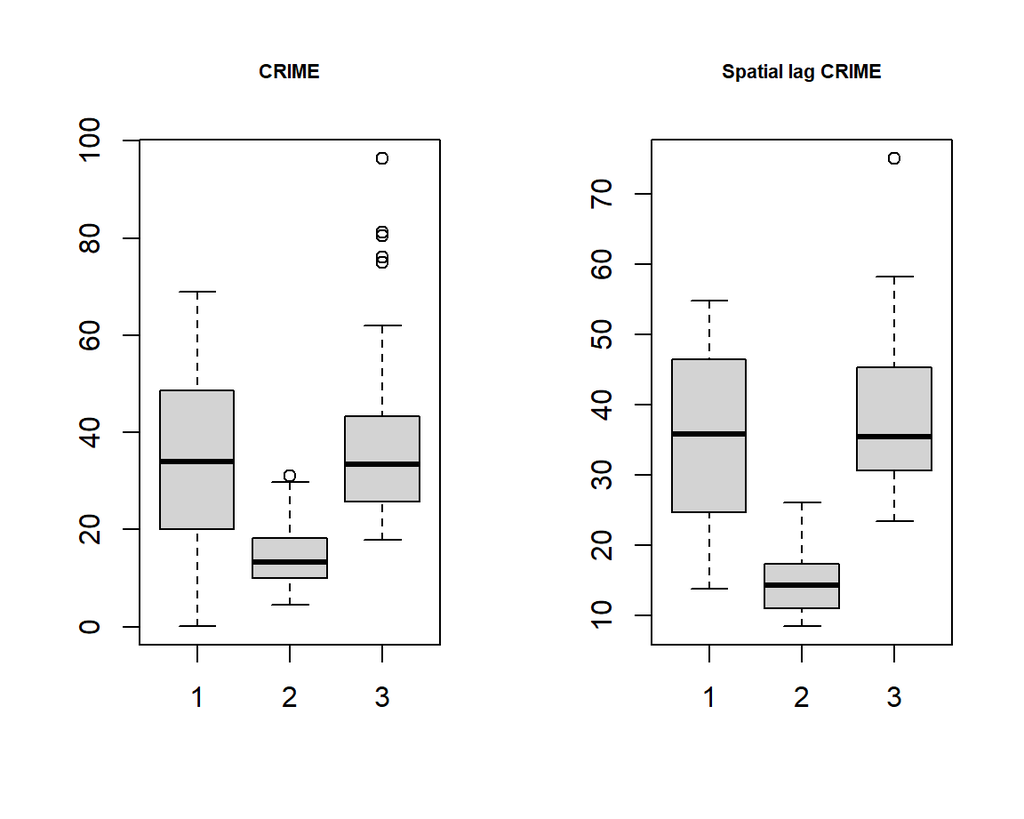

```r
par(mfrow=c(1,2),cex.main=0.7)
boxplot.matrix(xx,main="CRIME")
boxplot.matrix(wxx,main="Spatial lag CRIME")
```

- Comparaison de la densité

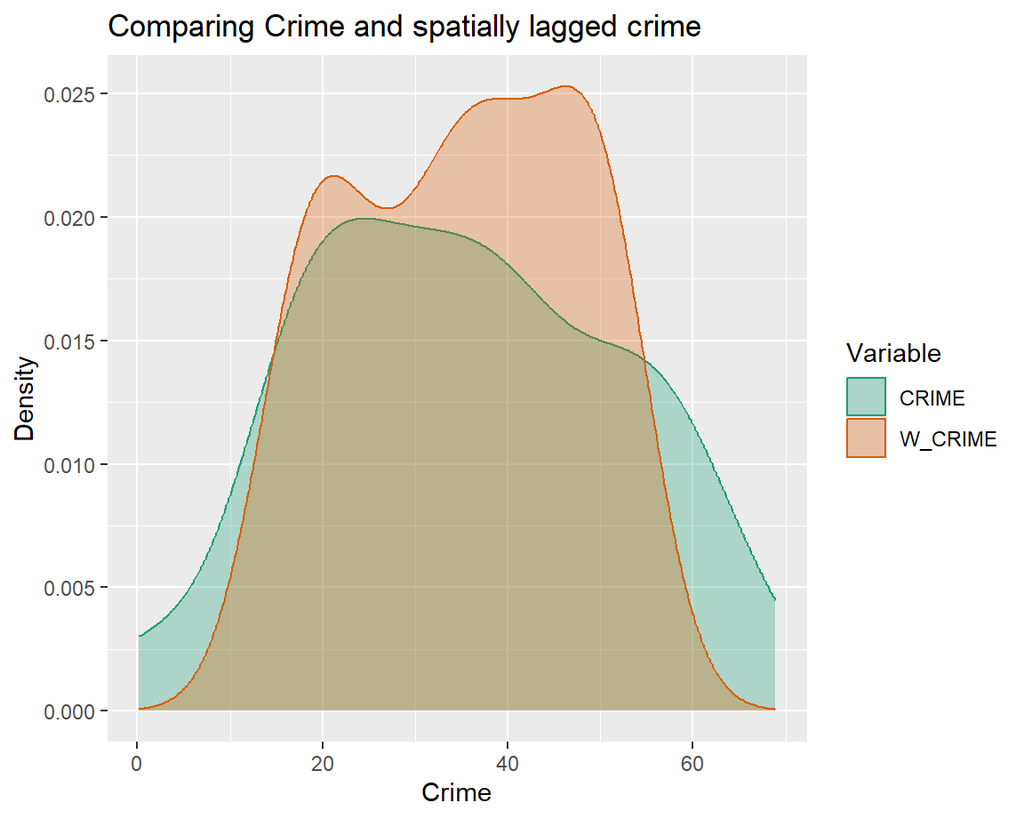

```r
columbus$W_CRIME <- wxx[,1]

columbus%>%st_drop_geometry() %>%
  pivot_longer(cols = c('CRIME','W_CRIME')) %>%
  ggplot() +
    geom_density(mapping = aes(x = value,
                          color = name, fill = name),
            alpha = 0.3) +
    scale_color_manual(values=brewer.pal(n = 2, name = "Dark2"))+
    scale_fill_manual(values=brewer.pal(n = 2, name = "Dark2")) +
    labs(x = "Crime", y = "Density",
       title = "Comparing Crime and spatially lagged crime",
       color = "Variable",
       fill = "Variable")
```

- Graphique de Moran

```r
lm(W_CRIME~CRIME, data=columbus)
```

```
Call:
lm(formula = W_CRIME ~ CRIME, data = columbus)

Coefficients:
(Intercept)        CRIME
    17.4797       0.5002
```

```r
summary(lm(W_CRIME~CRIME, data=columbus))
```

```
Call:
lm(formula = W_CRIME ~ CRIME, data = columbus)

Residuals:
    Min      1Q  Median      3Q     Max
-17.830  -5.866  -0.693   4.204  32.160

Coefficients:
            Estimate Std. Error t value Pr(>|t|)
(Intercept) 17.47974    3.02375   5.781 5.77e-07 ***
CRIME        0.50019    0.07786   6.424 6.12e-08 ***
---
Signif. codes:  0 '***' 0.001 '**' 0.01 '*' 0.05 '.' 0.1 ' ' 1

Residual standard error: 9.026 on 47 degrees of freedom
Multiple R-squared:  0.4676,    Adjusted R-squared:  0.4562
F-statistic: 41.27 on 1 and 47 DF,  p-value: 6.116e-08
```

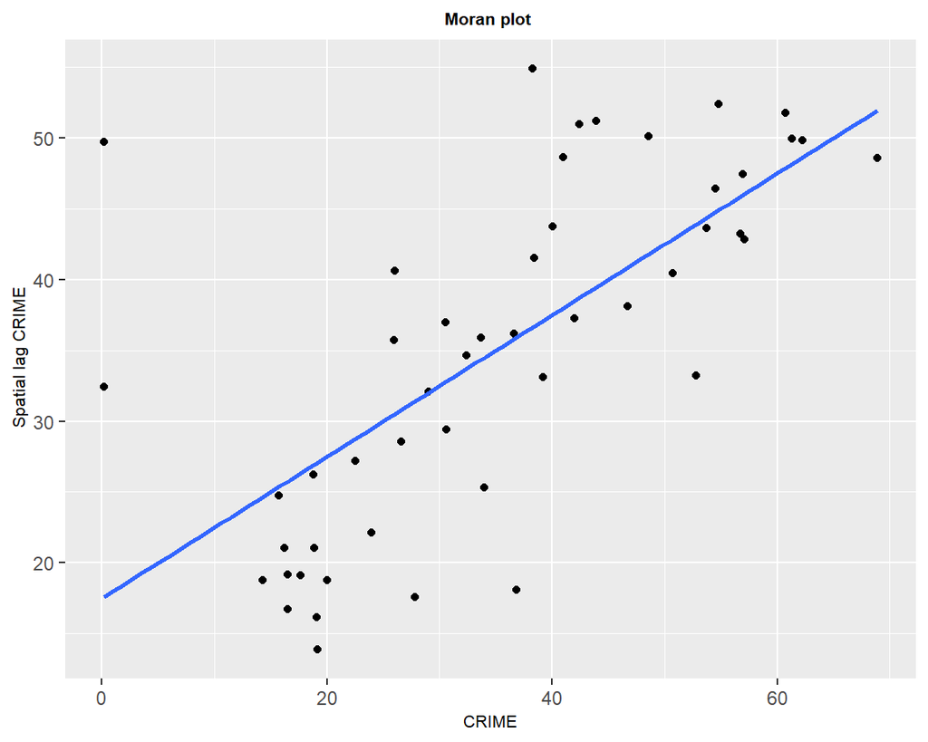

```r
ggplot(data = columbus, mapping = aes(x = CRIME, y = W_CRIME )) + geom_point()+labs(title = "Moran plot ", y = " Spatial lag CRIME" , x ="CRIME") + theme(plot.title = element_text(color = "black", size = 8, face = "bold",hjust = 0.5),  axis.title.x = element_text(color = "black", size = 8, hjust = 0.5),
  axis.title.y = element_text(color = "black", size = 8, hjust = 0.5)) + geom_smooth(method="lm", se=FALSE)
```

## 6 Indices d’autocorrélation spatiale

### 6.1 Indice global de Moran

- Test de Moran sur la variable CRIME

```r
morantesCRIME <-moran.test(columbus$CRIME,col.listw,randomisation=FALSE,alternative="greater")
morantesCRIME
```

```
    Moran I test under normality

data:  columbus$CRIME
weights: col.listw

Moran I statistic standard deviate = 5.6303, p-value = 8.994e-09
alternative hypothesis: greater
sample estimates:
Moran I statistic       Expectation          Variance
      0.500188557      -0.020833333       0.008563413
```

```r
morantesCRIME.MC <- moran.mc(columbus$CRIME, col.listw,99,alternative="greater")
morantesCRIME.MC
```

```
    Monte-Carlo simulation of Moran I

data:  columbus$CRIME
weights: col.listw
number of simulations + 1: 100

statistic = 0.50019, observed rank = 100, p-value = 0.01
alternative hypothesis: greater
```

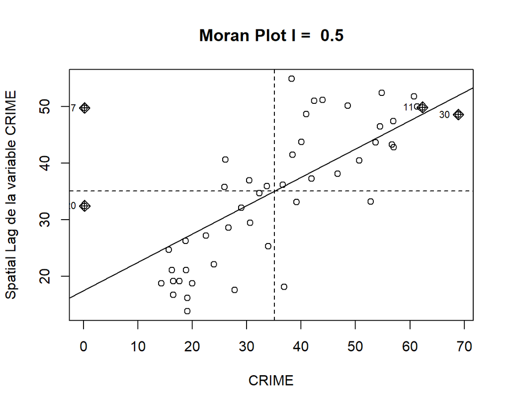

```r
moran.plot(x=columbus$CRIME,col.listw,xlab="CRIME",ylab="Spatial Lag de la variable CRIME",labels=as.character(columbus$POLYID),main=paste("Moran Plot I = ",round(morantesCRIME$estimate[1],3)))
```

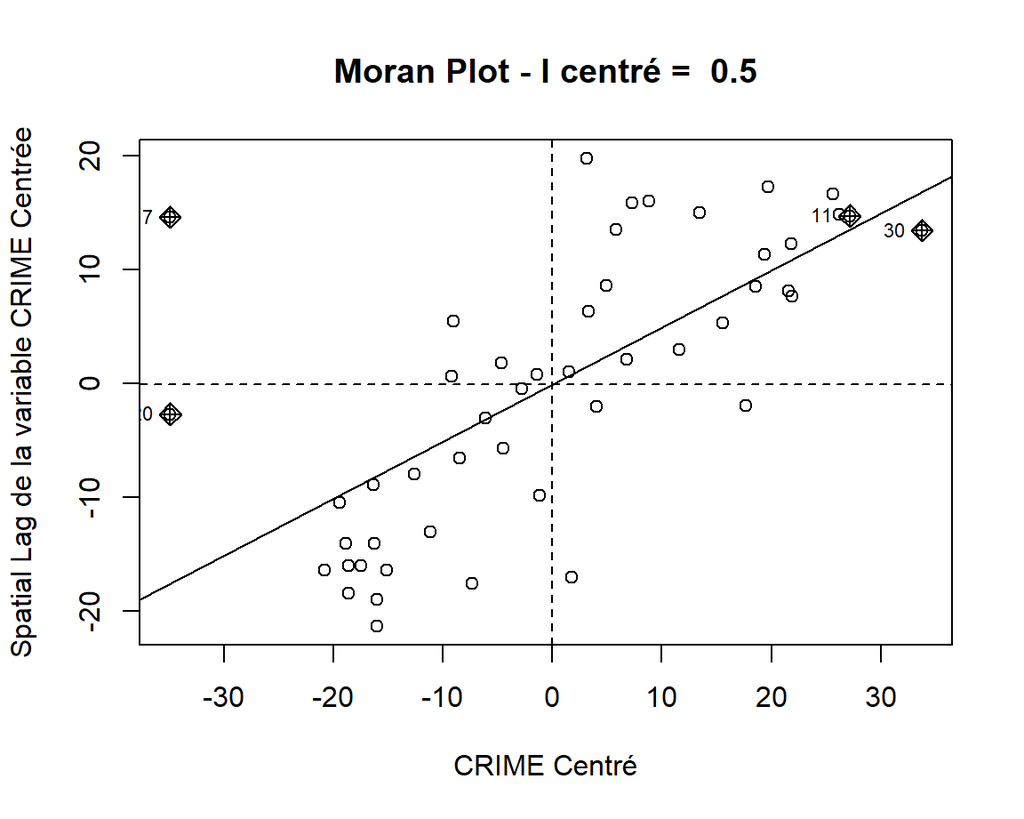

```r
columbus$CRIME_M <- columbus$CRIME-mean(columbus$CRIME)
moran.plot(x=columbus$CRIME_M,col.listw,xlab="CRIME Centré",ylab="Spatial Lag de la variable CRIME Centrée",labels=as.character(columbus$POLYID),main=paste("Moran Plot - I centré = ",round(morantesCRIME$estimate[1],3)))
```

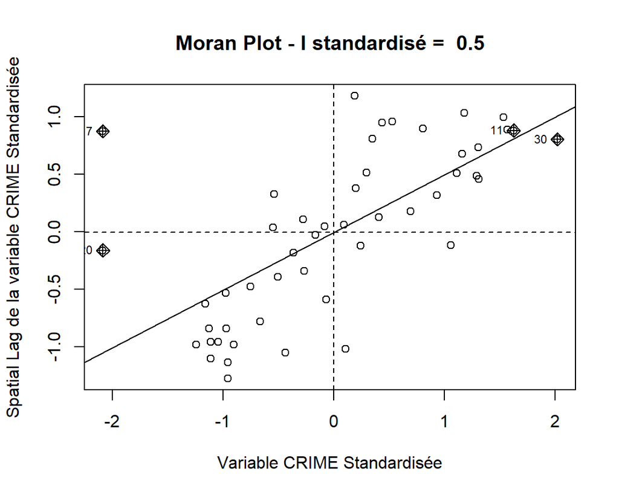

```r
columbus$CRIME_S<-columbus$CRIME_M/sd(columbus$CRIME)
moran.plot(x=columbus$CRIME_S,col.listw,xlab="Variable CRIME Standardisée",ylab="Spatial Lag de la variable CRIME Standardisée",labels=as.character(columbus$POLYID),main=paste("Moran Plot - I standardisé = ",round(morantesCRIME$estimate[1],3)))
```

- Test de Moran sur les autres variables

```r
morantestINC<- moran.test(columbus$INC,col.listw,randomisation=FALSE,alternative="greater")
morantestINC
```

```
    Moran I test under normality

data:  columbus$INC
weights: col.listw

Moran I statistic standard deviate = 4.7165, p-value = 1.199e-06
alternative hypothesis: greater
sample estimates:
Moran I statistic       Expectation          Variance
      0.415628778      -0.020833333       0.008563413
```

```r
morantestINC.MC <- moran.mc(columbus$INC, col.listw,99,alternative="greater")
morantestINC.MC
```

[output not shown]

```r
morantestHOVAL<- moran.test(columbus$HOVAL,col.listw,randomisation=FALSE,alternative="greater")
morantestHOVAL
```

```
    Moran I test under normality

data:  columbus$HOVAL
weights: col.listw

Moran I statistic standard deviate = 2.1713, p-value = 0.01496
alternative hypothesis: greater
sample estimates:
Moran I statistic       Expectation          Variance
      0.180093114      -0.020833333       0.008563413
```

```r
morantestHOVAL.MC <- moran.mc(columbus$HOVAL, col.listw,99,alternative="greater")
morantestHOVAL.MC
```

[output not shown]

### 6.2 Lisa - Indice local de Moran

- Calcul des indices sur les données brutes, centrées et standardisées

```r
locm <-localmoran(columbus$CRIME, col.listw)
head(locm)
```

```
            Ii          E.Ii      Var.Ii        Z.Ii Pr(z != E(Ii))
1  0.736818491 -0.0285985420 0.666144891  0.93780765      0.3483433
2  0.528777013 -0.0202502140 0.310266063  0.98565912      0.3243004
3  0.093850742 -0.0015396867 0.017630072  0.71841891      0.4724990
4  0.004820967 -0.0005707572 0.006541757  0.06666232      0.9468505
5  0.303606125 -0.0184931910 0.094617920  1.04713603      0.2950368
6 -0.181570517 -0.0062384562 0.148657003 -0.45474575      0.6492922
```

```r
summary(locm)
```

```
       Ii                E.Ii                Var.Ii              Z.Ii
 Min.   :-1.86059   Min.   :-9.279e-02   Min.   :0.001108   Min.   :-1.7992
 1st Qu.: 0.06795   1st Qu.:-2.857e-02   1st Qu.:0.029554   1st Qu.: 0.3982
 Median : 0.46768   Median :-1.728e-02   Median :0.149293   Median : 1.2857
 Mean   : 0.50019   Mean   :-2.083e-02   Mean   :0.206937   Mean   : 1.2168
 3rd Qu.: 0.96930   3rd Qu.:-2.827e-03   3rd Qu.:0.289330   3rd Qu.: 2.0611
 Max.   : 1.65517   Max.   :-9.665e-05   Max.   :0.965424   Max.   : 3.3607
 Pr(z != E(Ii))
 Min.   :0.0007776
 1st Qu.:0.0392923
 Median :0.1619765
 Mean   :0.2930883
 3rd Qu.:0.4518551
 Max.   :0.9522213
```

```r
locmc <-localmoran(columbus$CRIME_M, col.listw)
head(locmc)
```

```
            Ii          E.Ii      Var.Ii        Z.Ii Pr(z != E(Ii))
1  0.736818491 -0.0285985420 0.666144891  0.93780765      0.3483433
2  0.528777013 -0.0202502140 0.310266063  0.98565912      0.3243004
3  0.093850742 -0.0015396867 0.017630072  0.71841891      0.4724990
4  0.004820967 -0.0005707572 0.006541757  0.06666232      0.9468505
5  0.303606125 -0.0184931910 0.094617920  1.04713603      0.2950368
6 -0.181570517 -0.0062384562 0.148657003 -0.45474575      0.6492922
```

```r
summary(locmc)
```

```
       Ii                E.Ii                Var.Ii              Z.Ii
 Min.   :-1.86059   Min.   :-9.279e-02   Min.   :0.001108   Min.   :-1.7992
 1st Qu.: 0.06795   1st Qu.:-2.857e-02   1st Qu.:0.029554   1st Qu.: 0.3982
 Median : 0.46768   Median :-1.728e-02   Median :0.149293   Median : 1.2857
 Mean   : 0.50019   Mean   :-2.083e-02   Mean   :0.206937   Mean   : 1.2168
 3rd Qu.: 0.96930   3rd Qu.:-2.827e-03   3rd Qu.:0.289330   3rd Qu.: 2.0611
 Max.   : 1.65517   Max.   :-9.665e-05   Max.   :0.965424   Max.   : 3.3607
 Pr(z != E(Ii))
 Min.   :0.0007776
 1st Qu.:0.0392923
 Median :0.1619765
 Mean   :0.2930883
 3rd Qu.:0.4518551
 Max.   :0.9522213
```

```r
locms <-localmoran(columbus$CRIME_S, col.listw)
head(locms)
```

```
            Ii          E.Ii      Var.Ii        Z.Ii Pr(z != E(Ii))
1  0.736818491 -0.0285985420 0.666144891  0.93780765      0.3483433
2  0.528777013 -0.0202502140 0.310266063  0.98565912      0.3243004
3  0.093850742 -0.0015396867 0.017630072  0.71841891      0.4724990
4  0.004820967 -0.0005707572 0.006541757  0.06666232      0.9468505
5  0.303606125 -0.0184931910 0.094617920  1.04713603      0.2950368
6 -0.181570517 -0.0062384562 0.148657003 -0.45474575      0.6492922
```

```r
summary(locms)
```

```
       Ii                E.Ii                Var.Ii              Z.Ii
 Min.   :-1.86059   Min.   :-9.279e-02   Min.   :0.001108   Min.   :-1.7992
 1st Qu.: 0.06795   1st Qu.:-2.857e-02   1st Qu.:0.029554   1st Qu.: 0.3982
 Median : 0.46768   Median :-1.728e-02   Median :0.149293   Median : 1.2857
 Mean   : 0.50019   Mean   :-2.083e-02   Mean   :0.206937   Mean   : 1.2168
 3rd Qu.: 0.96930   3rd Qu.:-2.827e-03   3rd Qu.:0.289330   3rd Qu.: 2.0611
 Max.   : 1.65517   Max.   :-9.665e-05   Max.   :0.965424   Max.   : 3.3607
 Pr(z != E(Ii))
 Min.   :0.0007776
 1st Qu.:0.0392923
 Median :0.1619765
 Mean   :0.2930883
 3rd Qu.:0.4518551
 Max.   :0.9522213
```

- Cartographie des indices locaux

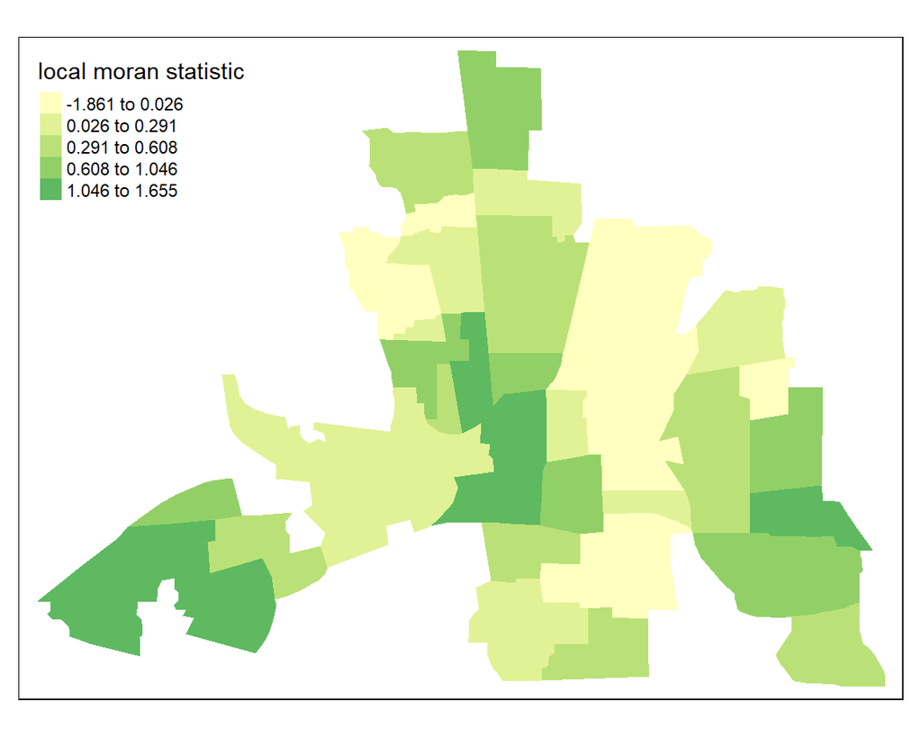

```r
moran.map <- cbind(columbus, locm)
tm_shape(moran.map) +
  tm_fill(col = "Ii",
          style = "quantile",
          title = "local moran statistic")
```

- Significativité des indices locaux

```r
x_crime_M <- cbind(columbus$CRIME_M)
wx_crime_M <- lag.listw(col.listw,x_crime_M) #spatial lag

quadrant <- vector(mode="numeric",length=nrow(locm))
signif <- 0.1

quadrant[x_crime_M>0 & wx_crime_M>0 & locmc[,5]<signif] <- 4  #High-High
quadrant[x_crime_M <0 & wx_crime_M<0  & locmc[,5]<signif] <- 1 #Low-Low
quadrant[x_crime_M<0 & wx_crime_M>0  & locmc[,5]<signif] <- 2  #Low_High
quadrant[x_crime_M >0 &wx_crime_M<0 & locmc[,5]<signif] <- 3 #High-Low
quadrant[locmc[,5]>signif] <- 0  #insignificant

table(quadrant)
```

```
quadrant
 0  1  2  3  4
30  6  1  1 11
```

```r
verif <- cbind(quadrant, locmc[,5])
```

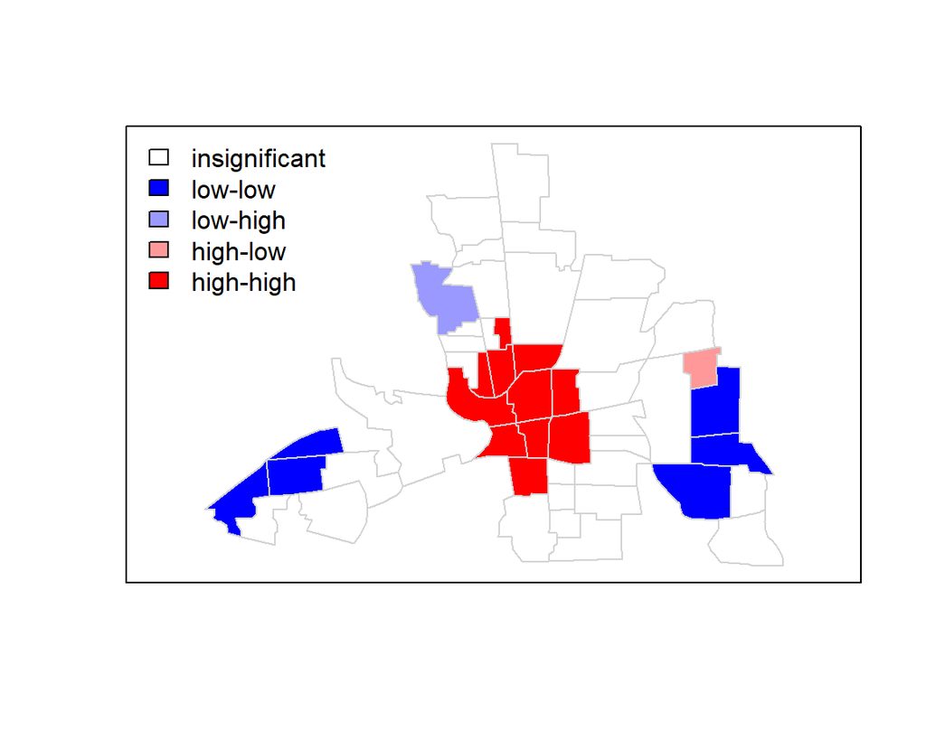

```r
brks <- c(0,1,2,3,4)
colors <- c("white","blue",rgb(0,0,1,alpha=0.4),rgb(1,0,0,alpha=0.4),"red")
plot(st_geometry(columbus),border="lightgray",col=colors[findInterval(quadrant,brks,all.inside=FALSE)])
box()
legend("topleft", legend = c("insignificant","low-low","low-high","high-low","high-high"),
       fill=colors,bty="n")
```

## 7 Indice globale C de Geary

- fonction **geary.test**

```r
geary.test(columbus$CRIME,col.listw, randomisation=FALSE, zero.policy=NULL,
    alternative="greater")
```

```
    Geary C test under normality

data:  columbus$CRIME
weights: col.listw

Geary C statistic standard deviate = 4.6363, p-value = 1.774e-06
alternative hypothesis: Expectation greater than statistic
sample estimates:
Geary C statistic       Expectation          Variance
      0.540528203       1.000000000       0.009821535
```

```r
geary.test(columbus$INC,col.listw, randomisation=FALSE, zero.policy=NULL,
    alternative="greater")
```

```
    Geary C test under normality

data:  columbus$INC
weights: col.listw

Geary C statistic standard deviate = 3.2705, p-value = 0.0005368
alternative hypothesis: Expectation greater than statistic
sample estimates:
Geary C statistic       Expectation          Variance
      0.675881625       1.000000000       0.009821535
```

```r
geary.test(columbus$HOVAL,col.listw, randomisation=FALSE, zero.policy=NULL,
    alternative="greater")
```

```
    Geary C test under normality

data:  columbus$HOVAL
weights: col.listw

Geary C statistic standard deviate = 1.9567, p-value = 0.02519
alternative hypothesis: Expectation greater than statistic
sample estimates:
Geary C statistic       Expectation          Variance
      0.806086397       1.000000000       0.009821535
```

- fonction **geary.mc**

```r
geary.mc(columbus$CRIME,col.listw,  nsim=99,alternative="greater")
```

```
    Monte-Carlo simulation of Geary C

data:  columbus$CRIME
weights: col.listw
number of simulations + 1: 100

statistic = 0.54053, observed rank = 1, p-value = 0.01
alternative hypothesis: greater
```

```r
geary.mc(columbus$INC,col.listw,  nsim=99,alternative="greater")
```

```
    Monte-Carlo simulation of Geary C

data:  columbus$INC
weights: col.listw
number of simulations + 1: 100

statistic = 0.67588, observed rank = 1, p-value = 0.01
alternative hypothesis: greater
```

```r
geary.mc(columbus$HOVAL,col.listw,  nsim=99,alternative="greater")
```

```
    Monte-Carlo simulation of Geary C

data:  columbus$HOVAL
weights: col.listw
number of simulations + 1: 100

statistic = 0.80609, observed rank = 6, p-value = 0.06
alternative hypothesis: greater
```